# Analyzing Mosquito Data

## Introduction

This material assumes that you have programmed before. This first lecture provides a quick introduction to programming in Python for those who either haven’t used Python before or need a quick refresher. Let’s start with a hypothetical problem we want to solve. We are interested in understanding the relationship between the weather and the number of mosquitos occuring in a particular year so that we can plan mosquito control measures accordingly. Since we want to apply these mosquito control measures at a number of different sites we need to understand both the relationship at a particular site and whether or not it is consistent across sites. The data we have to address this problem comes from the local government and are stored in tables in comma-separated values (CSV) files. Each file holds the data for a single location, each row holds the information for a single year at that location, and the columns hold the data on both mosquito numbers and the average temperature and rainfall from the beginning of mosquito breeding season. The first few rows of our first file look like:

[output not shown]

```python
# Import pandas (recall we can give it an alias)
import pandas as pd
data = pd.read_csv('data/A1_mosquito_data.csv')
data
```

|  | year | temperature | rainfall | mosquitos |
| --- | --- | --- | --- | --- |
| 0 | 2001 | 80 | 157 | 150 |
| 1 | 2002 | 85 | 252 | 217 |
| 2 | 2003 | 86 | 154 | 153 |
| 3 | 2004 | 87 | 159 | 158 |
| 4 | 2005 | 74 | 292 | 243 |
| 5 | 2006 | 75 | 283 | 237 |
| 6 | 2007 | 80 | 214 | 190 |
| 7 | 2008 | 85 | 197 | 181 |
| 8 | 2009 | 74 | 231 | 200 |
| 9 | 2010 | 74 | 207 | 184 |

```python
# What is the data type?
print(type(data))
```

```
<class 'pandas.core.frame.DataFrame'>
```

```python
# How many rows are there?
print("data has",len(data.index),"rows")

# Remamber numpy.shape()?
print("The shape is",data.shape)
print("...which means",data.shape[0],"rows and",data.shape[1],"columns")
```

```
data has 10 rows
The shape is (10, 4)
...which means 10 rows and 4 columns
```

```python
# Extract the year data
print(data['year'])
```

```
0    2001
1    2002
2    2003
3    2004
4    2005
5    2006
6    2007
7    2008
8    2009
9    2010
Name: year, dtype: int64
```

```python
# Extract the year and temperature
print(data[['rainfall', 'temperature']])
```

```
   rainfall  temperature
0       157           80
1       252           85
2       154           86
3       159           87
4       292           74
5       283           75
6       214           80
7       197           85
8       231           74
9       207           74
```

```python
# Slice the first two rows (by index)
print(data[0:2])
```

```
   year  temperature  rainfall  mosquitos
0  2001           80       157        150
1  2002           85       252        217
```

```python
# Try to slice just one row
data[0]
```

[output not shown]

[output cut: 13 more lines]

[output not shown]

```python
# You can slice single or multiple rows in with .iloc()
data.iloc[1:3]
```

|  | year | temperature | rainfall | mosquitos |
| --- | --- | --- | --- | --- |
| 1 | 2002 | 85 | 252 | 217 |
| 2 | 2003 | 86 | 154 | 153 |

```python
temps = data['temperature'][data['year'] > 2005]
print(type(temps))
temps_sf = temps.to_frame()
temps_sf
```

```
<class 'pandas.core.series.Series'>
```

|  | temperature |
| --- | --- |
| 5 | 75 |
| 6 | 80 |
| 7 | 85 |
| 8 | 74 |
| 9 | 74 |

```python
print(data['temperature'].max())
print(data['temperature'].mean())
```

```
87
80.0
```

```python
print(data['mosquitos'][1:3].std())
```

```
45.254833995939045
```

```python
# Challenge:
# Import the data from A2_mosquito_data.csv, create a new variable that
# holds a data frame with only the weather data, and print the means and
# standard deviations for the weather variables.
```

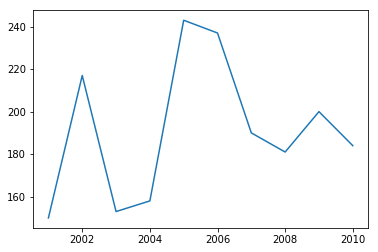

```python
%matplotlib inline
from matplotlib import pyplot as plt
plt.plot(data['year'], data['mosquitos'])
```

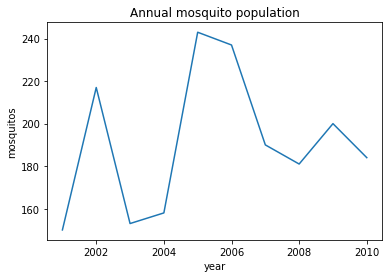

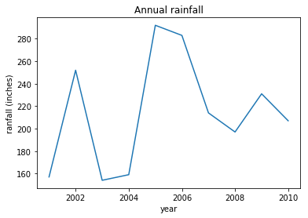

```python
# more...
plt.plot(data['year'], data['mosquitos'])
plt.title('Annual mosquito population')
plt.xlabel('year')
plt.ylabel('mosquitos')
plt.show()
plt.close()
plt.plot(data['year'], data['rainfall'])
plt.title('Annual rainfall')
plt.xlabel('year')
plt.ylabel('ranfall (inches)')
plt.show()
```

```
Text(0,0.5,'Rain Fall')
```

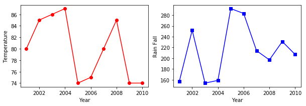

```python
# Finally, let's compare rainfall and temperature, side by side
plt.figure(figsize=(10.0, 3.0))

plt.subplot(1, 2, 1)
plt.plot(data['year'], data['temperature'], 'ro-')
plt.xlabel('Year')
plt.ylabel('Temperature')

plt.subplot(1, 2, 2)
plt.plot(data['year'], data['rainfall'], 'bs-')
plt.xlabel('Year')
plt.ylabel('Rain Fall')
```